# Project-2-GPA

2022-12-08

# An Investigation into GPA Statistics

## Md Abyan Wahed, MAW5683

## Introduction

Dataset: https://vincentarelbundock.github.io/Rdatasets/doc/Stat2Data/FirstYearGPA.html

My dataset, which I imported from the “interesting datasets” Google Docs spreadsheet provided on the project instructions, consisted of 11 variables and 219 observations. The variables are defined as follows:

student - Unique ID for the observation

GPA - Recorded GPA after freshman year of college (on 4.0 scale)

HSGPA - High School GPA (on 4.0 scale)

SATV - Reading SAT Score

SATM - Math SAT Score

Male - Gender (1 if Male, 0 if Female)

HU - High school credit hours in humanities courses

SS - High school credit hours in social sciences courses

FirstGen - 1 if a first-generation student, 0 if not

White - 1 if race of student is white, 0 if not

CollegeBound - 1 if attended high school with majority planning to go to college, 0 if not

```r
library(tidyverse)
```

```r
library(dplyr)
library(ggplot2)
library(rpart)
library(rpart.plot)
library(caret)
library(pROC)
library(ROCR)
library(randomForest)
library(ggfortify)
library(ggthemes)
```

Here, I import my dataset and give the first column a better variable name.

```r
gpa <- read_csv("~/Downloads/FirstYearGPA.csv")
```

```
## ──────────────────────────────────────────────────────── Delimiter: "," dbl
## (11): ...1, GPA, HSGPA, SATV, SATM, Male, HU, SS, FirstGen, White, Colle...
```

```r
gpa_1 <- gpa %>% rename(student = ...1)
```

## Logistic Regression

First, I want to predict whether a student is a first-generation student based on the other variables in the dataset.

```r
## Fitting model
glm_gpa <- glm(formula = FirstGen ~ GPA + HSGPA + SATV + SATM + Male + HU + SS + White + CollegeBound,
               family = binomial,
               data = gpa_1)

## Creating predicted class
pred_gpa <- predict(glm_gpa, gpa_1, type = 'response')
y_hat <- as.numeric(ifelse(pred_gpa > 0.5, "1", "0"))
mean(y_hat == gpa_1$FirstGen)
```

```
## [1] 0.8995434
```

```r
## Confusion Matrix, Specificity, Sensitivity
actual <- gpa_1$FirstGen
specificity(table(y_hat, actual))
```

```
## [1] 0.2
```

```r
sensitivity(table(y_hat, actual))
```

```
## [1] 0.9896907
```

```r
cM <- confusionMatrix(as.factor(y_hat), reference = as.factor(actual), positive = "1")
confusionMatrix(table(y_hat, actual))
```

```
## Confusion Matrix and Statistics
##
##      actual
## y_hat   0   1
##     0 192  20
##     1   2   5
##
##                Accuracy : 0.8995
##                  95% CI : (0.8519, 0.936)
##     No Information Rate : 0.8858
##     P-Value [Acc > NIR] : 0.3046085
##
##                   Kappa : 0.2764
##
##  Mcnemar's Test P-Value : 0.0002896
##
##             Sensitivity : 0.9897
##             Specificity : 0.2000
##          Pos Pred Value : 0.9057
##          Neg Pred Value : 0.7143
##              Prevalence : 0.8858
##          Detection Rate : 0.8767
##    Detection Prevalence : 0.9680
##       Balanced Accuracy : 0.5948
##
##        'Positive' Class : 0
##
```

```r
## AUC
df_1 <- data.frame(predictor = predict(glm_gpa, gpa_1, type = 'response'),
                   truth = gpa_1$FirstGen)
auc(truth ~ predictor, data = df_1)
```

```
## Area under the curve: 0.7977
```

The model resulted in an accuracy of around 89.95%, a sensitivity of around 99%, a specificity of 20%, and an area under the curve of 0.7977, which is overall lower than I thought considering I used every meaningful variable in the dataset as predictors.

## With Training and Test Sets

```r
## 1, Accuracy
set.seed(11172)
idx_train <- createDataPartition(gpa_1$FirstGen, p = 0.8)[[1]]
gpa_train <- gpa_1[idx_train,]
gpa_test <- gpa_1[-idx_train,]

train_glm <- glm(FirstGen ~ GPA + HSGPA + SATV + SATM + HU + SS + White + CollegeBound,
                 family = binomial,
                 data = gpa_train)
prob_test <- predict(train_glm, gpa_test, type = 'response')
predicted_test <- as.numeric(ifelse(prob_test > 0.5, "1", "0"))
mean(predicted_test == gpa_1$FirstGen)
```

```
## [1] 0.8493151
```

```r
## Sensitivity, Specificity
confusionMatrix(as.factor(predicted_test), reference = as.factor(gpa_test$FirstGen), positive = "1")
```

```
## Confusion Matrix and Statistics
##
##           Reference
## Prediction  0  1
##          0 37  3
##          1  1  2
##
##                Accuracy : 0.907
##                  95% CI : (0.7786, 0.9741)
##     No Information Rate : 0.8837
##     P-Value [Acc > NIR] : 0.4296
##
##                   Kappa : 0.4522
##
##  Mcnemar's Test P-Value : 0.6171
##
##             Sensitivity : 0.40000
##             Specificity : 0.97368
##          Pos Pred Value : 0.66667
##          Neg Pred Value : 0.92500
##              Prevalence : 0.11628
##          Detection Rate : 0.04651
##    Detection Prevalence : 0.06977
##       Balanced Accuracy : 0.68684
##
##        'Positive' Class : 1
##
```

```r
## AUC
df_2 <- data.frame(predictor = predict(train_glm, gpa_test, type = 'response'),
                   truth = gpa_test$FirstGen)
auc(truth ~ predictor, data = df_2)
```

```
## Area under the curve: 0.7053
```

```r
## 2, Accuracy
set.seed(17294)
idx_train <- createDataPartition(gpa_1$FirstGen, p = 0.8)[[1]]
gpa_train <- gpa_1[idx_train,]
gpa_test <- gpa_1[-idx_train,]

train_glm <- glm(FirstGen ~ GPA + HSGPA + SATV + SATM + HU + SS + White + CollegeBound,
                 family = binomial,
                 data = gpa_train)
prob_test <- predict(train_glm, gpa_test, type = 'response')
predicted_test <- as.numeric(ifelse(prob_test > 0.5, "1", "0"))
mean(predicted_test == gpa_1$FirstGen)
```

```
## [1] 0.8721461
```

```r
## Sensitivity, Specificity
confusionMatrix(as.factor(predicted_test), reference = as.factor(gpa_test$FirstGen), positive = "1")
```

```
## Confusion Matrix and Statistics
##
##           Reference
## Prediction  0  1
##          0 42  0
##          1  0  1
##
##                Accuracy : 1
##                  95% CI : (0.9178, 1)
##     No Information Rate : 0.9767
##     P-Value [Acc > NIR] : 0.3636
##
##                   Kappa : 1
##
##  Mcnemar's Test P-Value : NA
##
##             Sensitivity : 1.00000
##             Specificity : 1.00000
##          Pos Pred Value : 1.00000
##          Neg Pred Value : 1.00000
##              Prevalence : 0.02326
##          Detection Rate : 0.02326
##    Detection Prevalence : 0.02326
##       Balanced Accuracy : 1.00000
##
##        'Positive' Class : 1
##
```

```r
## AUC
df_3 <- data.frame(predictor = predict(train_glm, gpa_test, type = 'response'),
                   truth = gpa_test$FirstGen)
auc(truth ~ predictor, data = df_3)
```

```
## Area under the curve: 1
```

```r
## 3, Accuracy
set.seed(837)
idx_train <- createDataPartition(gpa_1$FirstGen, p = 0.8)[[1]]
gpa_train <- gpa_1[idx_train,]
gpa_test <- gpa_1[-idx_train,]

train_glm <- glm(FirstGen ~ GPA + HSGPA + SATV + SATM + HU + SS + White + CollegeBound,
                 family = binomial,
                 data = gpa_train)
prob_test <- predict(train_glm, gpa_test, type = 'response')
predicted_test <- as.numeric(ifelse(prob_test > 0.5, "1", "0"))
mean(predicted_test == gpa_1$FirstGen)
```

```
## [1] 0.8630137
```

```r
## Sensitivity, Specificity
confusionMatrix(as.factor(predicted_test), reference = as.factor(gpa_test$FirstGen), positive = "1")
```

```
## Confusion Matrix and Statistics
##
##           Reference
## Prediction  0  1
##          0 40  2
##          1  0  1
##
##                Accuracy : 0.9535
##                  95% CI : (0.8419, 0.9943)
##     No Information Rate : 0.9302
##     P-Value [Acc > NIR] : 0.4151
##
##                   Kappa : 0.4819
##
##  Mcnemar's Test P-Value : 0.4795
##
##             Sensitivity : 0.33333
##             Specificity : 1.00000
##          Pos Pred Value : 1.00000
##          Neg Pred Value : 0.95238
##              Prevalence : 0.06977
##          Detection Rate : 0.02326
##    Detection Prevalence : 0.02326
##       Balanced Accuracy : 0.66667
##
##        'Positive' Class : 1
##
```

```r
## AUC
df_4 <- data.frame(predictor = predict(train_glm, gpa_test, type = 'response'),
                   truth = gpa_test$FirstGen)
auc(truth ~ predictor, data = df_4)
```

```
## Area under the curve: 0.4083
```

```r
## 4, Accuracy
set.seed(12)
idx_train <- createDataPartition(gpa_1$FirstGen, p = 0.8)[[1]]
gpa_train <- gpa_1[idx_train,]
gpa_test <- gpa_1[-idx_train,]

train_glm <- glm(FirstGen ~ GPA + HSGPA + SATV + SATM + HU + SS + White + CollegeBound,
                 family = binomial,
                 data = gpa_train)
prob_test <- predict(train_glm, gpa_test, type = 'response')
predicted_test <- as.numeric(ifelse(prob_test > 0.5, "1", "0"))
mean(predicted_test == gpa_1$FirstGen)
```

```
## [1] 0.8858447
```

```r
## Sensitivity, Specificity
confusionMatrix(as.factor(predicted_test), reference = as.factor(gpa_test$FirstGen), positive = "1")
```

```
## Confusion Matrix and Statistics
##
##           Reference
## Prediction  0  1
##          0 39  4
##          1  0  0
##
##                Accuracy : 0.907
##                  95% CI : (0.7786, 0.9741)
##     No Information Rate : 0.907
##     P-Value [Acc > NIR] : 0.6290
##
##                   Kappa : 0
##
##  Mcnemar's Test P-Value : 0.1336
##
##             Sensitivity : 0.00000
##             Specificity : 1.00000
##          Pos Pred Value :     NaN
##          Neg Pred Value : 0.90698
##              Prevalence : 0.09302
##          Detection Rate : 0.00000
##    Detection Prevalence : 0.00000
##       Balanced Accuracy : 0.50000
##
##        'Positive' Class : 1
##
```

```r
## AUC
df_5 <- data.frame(predictor = predict(train_glm, gpa_test, type = 'response'),
                   truth = gpa_test$FirstGen)
auc(truth ~ predictor, data = df_5)
```

```
## Area under the curve: 0.8654
```

```r
## 5, Accuracy
set.seed(2348729)
idx_train <- createDataPartition(gpa_1$FirstGen, p = 0.8)[[1]]
gpa_train <- gpa_1[idx_train,]
gpa_test <- gpa_1[-idx_train,]

train_glm <- glm(FirstGen ~ GPA + HSGPA + SATV + SATM + HU + SS + White + CollegeBound,
                 family = binomial,
                 data = gpa_train)
prob_test <- predict(train_glm, gpa_test, type = 'response')
predicted_test <- as.numeric(ifelse(prob_test > 0.5, "1", "0"))
mean(predicted_test == gpa_1$FirstGen)
```

```
## [1] 0.8447489
```

```r
## Sensitivity, Specificity
confusionMatrix(as.factor(predicted_test), reference = as.factor(gpa_test$FirstGen), positive = "1")
```

```
## Confusion Matrix and Statistics
##
##           Reference
## Prediction  0  1
##          0 36  5
##          1  0  2
##
##                Accuracy : 0.8837
##                  95% CI : (0.7492, 0.9611)
##     No Information Rate : 0.8372
##     P-Value [Acc > NIR] : 0.27794
##
##                   Kappa : 0.4011
##
##  Mcnemar's Test P-Value : 0.07364
##
##             Sensitivity : 0.28571
##             Specificity : 1.00000
##          Pos Pred Value : 1.00000
##          Neg Pred Value : 0.87805
##              Prevalence : 0.16279
##          Detection Rate : 0.04651
##    Detection Prevalence : 0.04651
##       Balanced Accuracy : 0.64286
##
##        'Positive' Class : 1
##
```

```r
## AUC
df_6 <- data.frame(predictor = predict(train_glm, gpa_test, type = 'response'),
                   truth = gpa_test$FirstGen)
auc(truth ~ predictor, data = df_6)
```

```
## Area under the curve: 0.7738
```

## Tree-Based Classifiers

Now, I use rpart and randomForest.

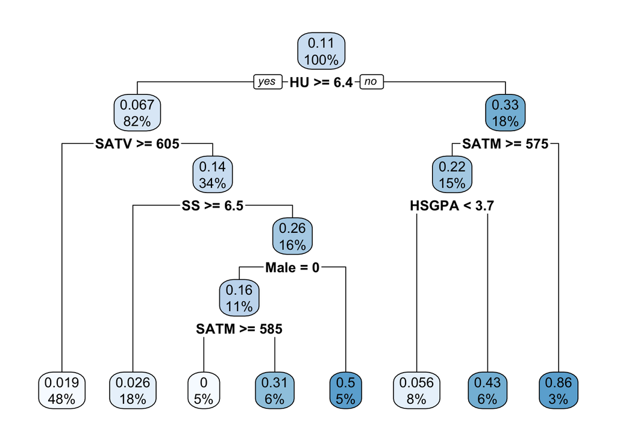

```r
## rpart
gpa_2 <- gpa_1 %>% dplyr::select(-student)
fitted_cart <- rpart(FirstGen ~.,
                     data = gpa_2)
rpart.plot(fitted_cart)
```

```r
## Accuracy
pred_cart <- predict(fitted_cart, gpa_2)
y_hat <- as.numeric(ifelse(pred_cart > 0.5, "1", "0"))
mean(y_hat == gpa_2$FirstGen)
```

```
## [1] 0.9086758
```

```r
## Sensitivity, specificity
confusionMatrix(as.factor(y_hat), as.factor(gpa_2$FirstGen), positive = "1")
```

```
## Confusion Matrix and Statistics
##
##           Reference
## Prediction   0   1
##          0 193  19
##          1   1   6
##
##                Accuracy : 0.9087
##                  95% CI : (0.8625, 0.9433)
##     No Information Rate : 0.8858
##     P-Value [Acc > NIR] : 0.1698577
##
##                   Kappa : 0.3421
##
##  Mcnemar's Test P-Value : 0.0001439
##
##             Sensitivity : 0.24000
##             Specificity : 0.99485
##          Pos Pred Value : 0.85714
##          Neg Pred Value : 0.91038
##              Prevalence : 0.11416
##          Detection Rate : 0.02740
##    Detection Prevalence : 0.03196
##       Balanced Accuracy : 0.61742
##
##        'Positive' Class : 1
##
```

```r
## AUC
df_7 <- data.frame(predictor = predict(fitted_cart, gpa_2),
                   truth = gpa_2$FirstGen)
auc(truth ~ predictor, data = df_7)
```

```
## Area under the curve: 0.8959
```

The rpart model resulted in an accuracy of 90.87%, a sensitivity of 24%, a specificity of 99.49%, and an area under the curve of 0.8959.

```r
## randomForest
gpa_2$FirstGen <- as.factor(gpa_2$FirstGen)
gpa_rf <- randomForest(FirstGen ~.,
                       data = gpa_2)

## Accuracy
pred_rf <- predict(gpa_rf, gpa_2)
mean(pred_rf == gpa_2$FirstGen)
```

```
## [1] 1
```

```r
## Sensitivity, specificity
confusionMatrix(as.factor(pred_rf), as.factor(gpa_2$FirstGen), positive = "1")
```

```
## Confusion Matrix and Statistics
##
##           Reference
## Prediction   0   1
##          0 194   0
##          1   0  25
##
##                Accuracy : 1
##                  95% CI : (0.9833, 1)
##     No Information Rate : 0.8858
##     P-Value [Acc > NIR] : 2.96e-12
##
##                   Kappa : 1
##
##  Mcnemar's Test P-Value : NA
##
##             Sensitivity : 1.0000
##             Specificity : 1.0000
##          Pos Pred Value : 1.0000
##          Neg Pred Value : 1.0000
##              Prevalence : 0.1142
##          Detection Rate : 0.1142
##    Detection Prevalence : 0.1142
##       Balanced Accuracy : 1.0000
##
##        'Positive' Class : 1
##
```

```r
## AUC
rf_p_gpa <- predict(gpa_rf, type = "prob", gpa_2)[,2]
rf_pr_gpa <- prediction(rf_p_gpa, gpa_2$FirstGen)
rf_auc <- performance(rf_pr_gpa, measure = "auc")@y.values[[1]]
rf_auc
```

```
## [1] 1
```

The randomForest model produced an accuracy of 100%.

## Training and Testing Sets

Here, I apply training and testing sets to the rpart model.

```r
##rpart - 1
set.seed(11172)
idx_train <- createDataPartition(gpa_2$FirstGen, p = 0.8)[[1]]
gpa_train <- gpa_2[idx_train,]
gpa_test <- gpa_2[-idx_train,]

train_cart <- rpart(FirstGen ~. ,
                    data = gpa_train)
pred_train <- predict(train_cart, gpa_test)
y_hat <- as.numeric(ifelse(pred_train[,2] > 0.5, "1", "0"))
mean(y_hat == gpa_2$FirstGen)
```

```
## [1] 0.8858447
```

```r
## Sensitivity, specificity
confusionMatrix(as.factor(y_hat), as.factor(gpa_test$FirstGen), positive = "1")
```

```
## Confusion Matrix and Statistics
##
##           Reference
## Prediction  0  1
##          0 38  5
##          1  0  0
##
##                Accuracy : 0.8837
##                  95% CI : (0.7492, 0.9611)
##     No Information Rate : 0.8837
##     P-Value [Acc > NIR] : 0.61618
##
##                   Kappa : 0
##
##  Mcnemar's Test P-Value : 0.07364
##
##             Sensitivity : 0.0000
##             Specificity : 1.0000
##          Pos Pred Value :    NaN
##          Neg Pred Value : 0.8837
##              Prevalence : 0.1163
##          Detection Rate : 0.0000
##    Detection Prevalence : 0.0000
##       Balanced Accuracy : 0.5000
##
##        'Positive' Class : 1
##
```

```r
## AUC
auc(gpa_test$FirstGen, y_hat)
```

```
## Area under the curve: 0.5
```

```r
## 2
set.seed(17294)
idx_train <- createDataPartition(gpa_2$FirstGen, p = 0.8)[[1]]
gpa_train <- gpa_2[idx_train,]
gpa_test <- gpa_2[-idx_train,]

train_cart <- rpart(FirstGen ~. ,
                    data = gpa_train)
pred_train <- predict(train_cart, gpa_test)
y_hat <- as.numeric(ifelse(pred_train[,2] > 0.5, "1", "0"))
mean(y_hat == gpa_2$FirstGen)
```

```
## [1] 0.8173516
```

```r
## Sensitivity, specificity
confusionMatrix(as.factor(y_hat), as.factor(gpa_test$FirstGen), positive = "1")
```

```
## Confusion Matrix and Statistics
##
##           Reference
## Prediction  0  1
##          0 34  5
##          1  4  0
##
##                Accuracy : 0.7907
##                  95% CI : (0.6396, 0.8996)
##     No Information Rate : 0.8837
##     P-Value [Acc > NIR] : 0.9766
##
##                   Kappa : -0.1153
##
##  Mcnemar's Test P-Value : 1.0000
##
##             Sensitivity : 0.00000
##             Specificity : 0.89474
##          Pos Pred Value : 0.00000
##          Neg Pred Value : 0.87179
##              Prevalence : 0.11628
##          Detection Rate : 0.00000
##    Detection Prevalence : 0.09302
##       Balanced Accuracy : 0.44737
##
##        'Positive' Class : 1
##
```

```r
## AUC
auc(gpa_test$FirstGen, y_hat)
```

```
## Area under the curve: 0.4474
```

```r
## 3
set.seed(837)
idx_train <- createDataPartition(gpa_2$FirstGen, p = 0.8)[[1]]
gpa_train <- gpa_2[idx_train,]
gpa_test <- gpa_2[-idx_train,]

train_cart <- rpart(FirstGen ~. ,
                    data = gpa_train)
pred_train <- predict(train_cart, gpa_test)
y_hat <- as.numeric(ifelse(pred_train[,2] > 0.5, "1", "0"))
mean(y_hat == gpa_2$FirstGen)
```

```
## [1] 0.8219178
```

```r
## Sensitivity, specificity
confusionMatrix(as.factor(y_hat), as.factor(gpa_test$FirstGen), positive = "1")
```

```
## Confusion Matrix and Statistics
##
##           Reference
## Prediction  0  1
##          0 35  5
##          1  3  0
##
##                Accuracy : 0.814
##                  95% CI : (0.666, 0.9161)
##     No Information Rate : 0.8837
##     P-Value [Acc > NIR] : 0.9439
##
##                   Kappa : -0.0955
##
##  Mcnemar's Test P-Value : 0.7237
##
##             Sensitivity : 0.00000
##             Specificity : 0.92105
##          Pos Pred Value : 0.00000
##          Neg Pred Value : 0.87500
##              Prevalence : 0.11628
##          Detection Rate : 0.00000
##    Detection Prevalence : 0.06977
##       Balanced Accuracy : 0.46053
##
##        'Positive' Class : 1
##
```

```r
## AUC
auc(gpa_test$FirstGen, y_hat)
```

```
## Area under the curve: 0.4605
```

```r
## 4
set.seed(12)
idx_train <- createDataPartition(gpa_2$FirstGen, p = 0.8)[[1]]
gpa_train <- gpa_2[idx_train,]
gpa_test <- gpa_2[-idx_train,]

train_cart <- rpart(FirstGen ~. ,
                    data = gpa_train)
pred_train <- predict(train_cart, gpa_test)
y_hat <- as.numeric(ifelse(pred_train[,2] > 0.5, "1", "0"))
mean(y_hat == gpa_2$FirstGen)
```

```
## [1] 0.8858447
```

```r
## Sensitivity, specificity
confusionMatrix(as.factor(y_hat), as.factor(gpa_test$FirstGen), positive = "1")
```

```
## Confusion Matrix and Statistics
##
##           Reference
## Prediction  0  1
##          0 38  5
##          1  0  0
##
##                Accuracy : 0.8837
##                  95% CI : (0.7492, 0.9611)
##     No Information Rate : 0.8837
##     P-Value [Acc > NIR] : 0.61618
##
##                   Kappa : 0
##
##  Mcnemar's Test P-Value : 0.07364
##
##             Sensitivity : 0.0000
##             Specificity : 1.0000
##          Pos Pred Value :    NaN
##          Neg Pred Value : 0.8837
##              Prevalence : 0.1163
##          Detection Rate : 0.0000
##    Detection Prevalence : 0.0000
##       Balanced Accuracy : 0.5000
##
##        'Positive' Class : 1
##
```

```r
## AUC
auc(gpa_test$FirstGen, y_hat)
```

```
## Area under the curve: 0.5
```

```r
## 5
set.seed(2348729)
idx_train <- createDataPartition(gpa_2$FirstGen, p = 0.8)[[1]]
gpa_train <- gpa_2[idx_train,]
gpa_test <- gpa_2[-idx_train,]

train_cart <- rpart(FirstGen ~. ,
                    data = gpa_train)
pred_train <- predict(train_cart, gpa_test)
y_hat <- as.numeric(ifelse(pred_train[,2] > 0.5, "1", "0"))
mean(y_hat == gpa_2$FirstGen)
```

```
## [1] 0.8630137
```

```r
## Sensitivity, specificity
confusionMatrix(as.factor(y_hat), as.factor(gpa_test$FirstGen), positive = "1")
```

```
## Confusion Matrix and Statistics
##
##           Reference
## Prediction  0  1
##          0 36  5
##          1  2  0
##
##                Accuracy : 0.8372
##                  95% CI : (0.693, 0.9319)
##     No Information Rate : 0.8837
##     P-Value [Acc > NIR] : 0.8798
##
##                   Kappa : -0.0712
##
##  Mcnemar's Test P-Value : 0.4497
##
##             Sensitivity : 0.00000
##             Specificity : 0.94737
##          Pos Pred Value : 0.00000
##          Neg Pred Value : 0.87805
##              Prevalence : 0.11628
##          Detection Rate : 0.00000
##    Detection Prevalence : 0.04651
##       Balanced Accuracy : 0.47368
##
##        'Positive' Class : 1
##
```

```r
## AUC
auc(gpa_test$FirstGen, y_hat)
```

```
## Area under the curve: 0.4737
```

Then, I repeat the process with the randomForest model.

```r
## randomForest - 1
set.seed(11172)
idx_train <- createDataPartition(gpa_2$FirstGen, p = 0.8)[[1]]
gpa_train <- gpa_2[idx_train,]
gpa_test <- gpa_2[-idx_train,]

train_rf <- randomForest(FirstGen ~.,
                       data = gpa_train)

## Accuracy
pred_rf <- predict(train_rf, gpa_test)
mean(pred_rf == gpa_2$FirstGen)
```

```
## [1] 0.8858447
```

```r
## Sensitivity, specificity
confusionMatrix(as.factor(pred_rf), as.factor(gpa_test$FirstGen), positive = "1")
```

```
## Confusion Matrix and Statistics
##
##           Reference
## Prediction  0  1
##          0 38  5
##          1  0  0
##
##                Accuracy : 0.8837
##                  95% CI : (0.7492, 0.9611)
##     No Information Rate : 0.8837
##     P-Value [Acc > NIR] : 0.61618
##
##                   Kappa : 0
##
##  Mcnemar's Test P-Value : 0.07364
##
##             Sensitivity : 0.0000
##             Specificity : 1.0000
##          Pos Pred Value :    NaN
##          Neg Pred Value : 0.8837
##              Prevalence : 0.1163
##          Detection Rate : 0.0000
##    Detection Prevalence : 0.0000
##       Balanced Accuracy : 0.5000
##
##        'Positive' Class : 1
##
```

```r
## AUC
rf_p_gpa <- predict(gpa_rf, type = "prob", gpa_test)[,2]
rf_pr_gpa <- prediction(rf_p_gpa, gpa_test$FirstGen)
rf_auc <- performance(rf_pr_gpa, measure = "auc")@y.values[[1]]
rf_auc
```

```
## [1] 1
```

```r
## randomForest - 2
set.seed(17294)
idx_train <- createDataPartition(gpa_2$FirstGen, p = 0.8)[[1]]
gpa_train <- gpa_2[idx_train,]
gpa_test <- gpa_2[-idx_train,]

train_rf <- randomForest(FirstGen ~.,
                       data = gpa_train)

## Accuracy
pred_rf <- predict(train_rf, gpa_test)
mean(pred_rf == gpa_2$FirstGen)
```

```
## [1] 0.8858447
```

```r
## Sensitivity, specificity
confusionMatrix(as.factor(pred_rf), as.factor(gpa_test$FirstGen), positive = "1")
```

```
## Confusion Matrix and Statistics
##
##           Reference
## Prediction  0  1
##          0 38  5
##          1  0  0
##
##                Accuracy : 0.8837
##                  95% CI : (0.7492, 0.9611)
##     No Information Rate : 0.8837
##     P-Value [Acc > NIR] : 0.61618
##
##                   Kappa : 0
##
##  Mcnemar's Test P-Value : 0.07364
##
##             Sensitivity : 0.0000
##             Specificity : 1.0000
##          Pos Pred Value :    NaN
##          Neg Pred Value : 0.8837
##              Prevalence : 0.1163
##          Detection Rate : 0.0000
##    Detection Prevalence : 0.0000
##       Balanced Accuracy : 0.5000
##
##        'Positive' Class : 1
##
```

```r
## AUC
rf_p_gpa <- predict(gpa_rf, type = "prob", gpa_test)[,2]
rf_pr_gpa <- prediction(rf_p_gpa, gpa_test$FirstGen)
rf_auc <- performance(rf_pr_gpa, measure = "auc")@y.values[[1]]
rf_auc
```

```
## [1] 1
```

```r
## randomForest - 3
set.seed(837)
idx_train <- createDataPartition(gpa_2$FirstGen, p = 0.8)[[1]]
gpa_train <- gpa_2[idx_train,]
gpa_test <- gpa_2[-idx_train,]

train_rf <- randomForest(FirstGen ~.,
                       data = gpa_train)

## Accuracy
pred_rf <- predict(train_rf, gpa_test)
mean(pred_rf == gpa_2$FirstGen)
```

```
## [1] 0.8219178
```

```r
## Sensitivity, specificity
confusionMatrix(as.factor(pred_rf), as.factor(gpa_test$FirstGen), positive = "1")
```

```
## Confusion Matrix and Statistics
##
##           Reference
## Prediction  0  1
##          0 35  5
##          1  3  0
##
##                Accuracy : 0.814
##                  95% CI : (0.666, 0.9161)
##     No Information Rate : 0.8837
##     P-Value [Acc > NIR] : 0.9439
##
##                   Kappa : -0.0955
##
##  Mcnemar's Test P-Value : 0.7237
##
##             Sensitivity : 0.00000
##             Specificity : 0.92105
##          Pos Pred Value : 0.00000
##          Neg Pred Value : 0.87500
##              Prevalence : 0.11628
##          Detection Rate : 0.00000
##    Detection Prevalence : 0.06977
##       Balanced Accuracy : 0.46053
##
##        'Positive' Class : 1
##
```

```r
## AUC
rf_p_gpa <- predict(gpa_rf, type = "prob", gpa_test)[,2]
rf_pr_gpa <- prediction(rf_p_gpa, gpa_test$FirstGen)
rf_auc <- performance(rf_pr_gpa, measure = "auc")@y.values[[1]]
rf_auc
```

```
## [1] 1
```

```r
## randomForest - 4
set.seed(12)
idx_train <- createDataPartition(gpa_2$FirstGen, p = 0.8)[[1]]
gpa_train <- gpa_2[idx_train,]
gpa_test <- gpa_2[-idx_train,]

train_rf <- randomForest(FirstGen ~.,
                       data = gpa_train)

## Accuracy
pred_rf <- predict(train_rf, gpa_test)
mean(pred_rf == gpa_2$FirstGen)
```

```
## [1] 0.8584475
```

```r
## Sensitivity, specificity
confusionMatrix(as.factor(pred_rf), as.factor(gpa_test$FirstGen), positive = "1")
```

```
## Confusion Matrix and Statistics
##
##           Reference
## Prediction  0  1
##          0 37  5
##          1  1  0
##
##                Accuracy : 0.8605
##                  95% CI : (0.7207, 0.947)
##     No Information Rate : 0.8837
##     P-Value [Acc > NIR] : 0.7717
##
##                   Kappa : -0.0403
##
##  Mcnemar's Test P-Value : 0.2207
##
##             Sensitivity : 0.00000
##             Specificity : 0.97368
##          Pos Pred Value : 0.00000
##          Neg Pred Value : 0.88095
##              Prevalence : 0.11628
##          Detection Rate : 0.00000
##    Detection Prevalence : 0.02326
##       Balanced Accuracy : 0.48684
##
##        'Positive' Class : 1
##
```

```r
## AUC
rf_p_gpa <- predict(gpa_rf, type = "prob", gpa_test)[,2]
rf_pr_gpa <- prediction(rf_p_gpa, gpa_test$FirstGen)
rf_auc <- performance(rf_pr_gpa, measure = "auc")@y.values[[1]]
rf_auc
```

```
## [1] 1
```

```r
## randomForest - 5
set.seed(2348729)
idx_train <- createDataPartition(gpa_2$FirstGen, p = 0.8)[[1]]
gpa_train <- gpa_2[idx_train,]
gpa_test <- gpa_2[-idx_train,]

train_rf <- randomForest(FirstGen ~.,
                       data = gpa_train)

## Accuracy
pred_rf <- predict(train_rf, gpa_test)
mean(pred_rf == gpa_2$FirstGen)
```

```
## [1] 0.8401826
```

```r
## Sensitivity, specificity
confusionMatrix(as.factor(pred_rf), as.factor(gpa_test$FirstGen), positive = "1")
```

```
## Confusion Matrix and Statistics
##
##           Reference
## Prediction  0  1
##          0 36  5
##          1  2  0
##
##                Accuracy : 0.8372
##                  95% CI : (0.693, 0.9319)
##     No Information Rate : 0.8837
##     P-Value [Acc > NIR] : 0.8798
##
##                   Kappa : -0.0712
##
##  Mcnemar's Test P-Value : 0.4497
##
##             Sensitivity : 0.00000
##             Specificity : 0.94737
##          Pos Pred Value : 0.00000
##          Neg Pred Value : 0.87805
##              Prevalence : 0.11628
##          Detection Rate : 0.00000
##    Detection Prevalence : 0.04651
##       Balanced Accuracy : 0.47368
##
##        'Positive' Class : 1
##
```

```r
## AUC
rf_p_gpa <- predict(gpa_rf, type = "prob", gpa_test)[,2]
rf_pr_gpa <- prediction(rf_p_gpa, gpa_test$FirstGen)
rf_auc <- performance(rf_pr_gpa, measure = "auc")@y.values[[1]]
rf_auc
```

```
## [1] 1
```

The rpart model showed signs of overfitting when adding training and testing sets as the accuracy seemed to decrease. The same can be said about the randomForest model when adding training/test splits.

## Caret

I attempt to find the best possible value of ‘cp’ using cross-validation.

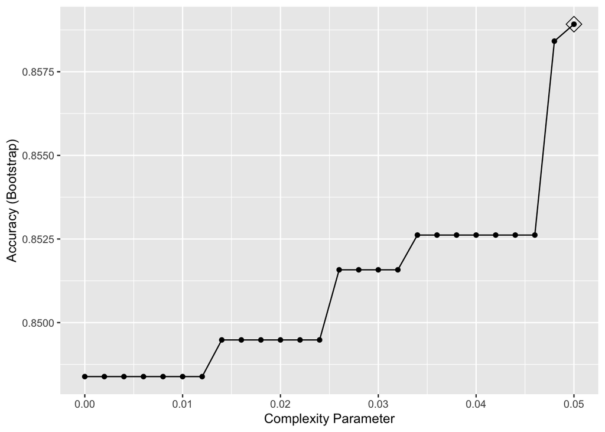

```r
tune_grid <- data.frame(cp = seq(from = 0, to = 0.05, by = 0.002))
colnames(gpa_2) <- make.names(colnames(gpa_2))

trained_rpart <- train(
  FirstGen ~ .,
  data = gpa_2,
  method = 'rpart',
  tuneGrid = tune_grid,
  control = rpart.control(minsplit = 20)
)

ggplot(trained_rpart, highlight = TRUE)
```

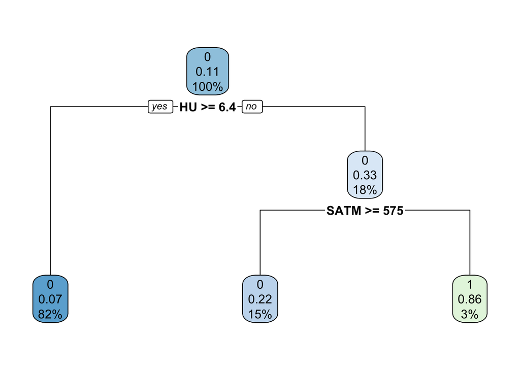

```r
optimal_cart <- rpart(FirstGen ~. ,
      data = gpa_2,
      control = rpart.control(cp = 0.05))

rpart.plot(optimal_cart)
```

To my understanding, this tree first determines whether the student has more than 6.4 humanities credits. If so, they are predicted not to be a first-generation student (which is 82% of the data). If not, the tree then determines whether their Math SAT score was above 575. If it is above, then the tree predicts the student not to be a first-generation student. If below a 575 math score and less than 6.4 humanities credits, the student is predicted to be a first-generation student, which is 3% of the data.

## Linear Regression

```r
## Linear model
gpa_lm <- lm(GPA ~ HSGPA + SATV + SATM,
             data = gpa_2)
summary(gpa_lm)
```

```
##
## Call:
## lm(formula = GPA ~ HSGPA + SATV + SATM, data = gpa_2)
##
## Residuals:
##      Min       1Q   Median       3Q      Max
## -0.97999 -0.27898  0.03614  0.29873  0.88376
##
## Coefficients:
##              Estimate Std. Error t value Pr(>|t|)
## (Intercept) 0.5877912  0.3269497   1.798  0.07361 .
## HSGPA       0.4962319  0.0753072   6.589 3.35e-10 ***
## SATV        0.0011595  0.0003935   2.946  0.00357 **
## SATM        0.0001473  0.0004315   0.341  0.73310
## ---
## Signif. codes:  0 '***' 0.001 '**' 0.01 '*' 0.05 '.' 0.1 ' ' 1
##
## Residual standard error: 0.4069 on 215 degrees of freedom
## Multiple R-squared:  0.2464, Adjusted R-squared:  0.2359
## F-statistic: 23.43 on 3 and 215 DF,  p-value: 3.666e-13
```

```r
## RMSE
pred_lm <- round((predict(gpa_lm, gpa_2)), digits = 2)
sqrt(mean((gpa_2$GPA - pred_lm)^2))
```

```
## [1] 0.4027321
```

```r
## k-fold cross validation
set.seed(229)
train_control <- trainControl(method = "repeatedcv", number = 20, repeats = 5)
cv_lm <- train(GPA ~ HSGPA + SATV + SATM,
               data = gpa_2,
               method = "lm",
               trControl = train_control)
print(cv_lm$results)
```

```
##   intercept      RMSE  Rsquared       MAE     RMSESD RsquaredSD      MAESD
## 1      TRUE 0.4037284 0.3005539 0.3326261 0.06825568  0.2164389 0.06438811
```

```r
## cv using randomForest
possible_cps <- data.frame(cp = seq(from = 0.001, to = 0.05, length = 20))
set.seed(229)
cv_cart <- train(GPA ~ HSGPA + SATV + SATM,
                 data = gpa_2,
                 method = "rpart",
                 tuneGrid = possible_cps,
                 trControl = train_control)
cv_cart$results %>% slice_min(RMSE)
```

```
##           cp      RMSE  Rsquared       MAE     RMSESD RsquaredSD     MAESD
## 1 0.02678947 0.4414244 0.2067644 0.3651458 0.07667588  0.1789445 0.0658465
```

## Unsupervised Learning: PCA

```r
gpa_3 <- gpa_1 %>% dplyr::select(-student, -Male, -White, -FirstGen, -CollegeBound)
pca <- gpa_3 %>% scale() %>% prcomp()
pca
```

```
## Standard deviations (1, .., p=6):
## [1] 1.4201336 1.1302287 1.0427942 0.8450728 0.6813371 0.6633367
##
## Rotation (n x k) = (6 x 6):
##              PC1         PC2         PC3         PC4        PC5        PC6
## GPA    0.5148531 -0.11330314  0.41377345 -0.18750761  0.6678621 -0.2639722
## HSGPA  0.4313900 -0.01391426  0.49734810  0.61117988 -0.3989462  0.1834532
## SATV   0.5004034  0.33459735 -0.28105578 -0.23824412 -0.4409236 -0.5545041
## SATM   0.4326802  0.39520761 -0.44999432  0.06361199  0.2724546  0.6130464
## HU     0.2981314 -0.64153822 -0.03544788 -0.51242891 -0.3143282  0.3700057
## SS    -0.1494352  0.55430412  0.54652777 -0.51760015 -0.1653929  0.2765117
```

```r
pca_data <- data.frame(pca$x, FirstGen = gpa_2$FirstGen)
head(pca_data)
```

```
##          PC1         PC2        PC3        PC4         PC5        PC6 FirstGen
## 1  1.1548541  2.10002291 -0.3547567  1.0661297  0.02366716  0.3918763        1
## 2  3.0555378  0.60856618  0.2513723  0.8860922  0.84574653 -0.9739335        0
## 3  0.4190450  0.09761053  1.4883054 -0.6777955 -0.54646433 -0.3469607        0
## 4  1.9629224 -0.73643517 -1.5065014 -0.1627273 -0.52018209 -0.3437787        0
## 5  1.6381607 -2.39690359  0.2568215 -0.2125241 -0.53141655  0.3090576        0
## 6 -0.4663412 -1.22033935 -0.4857365 -0.2187589 -0.27223071 -0.4909485        0
```

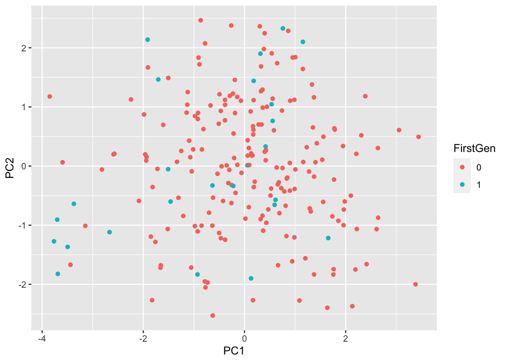

```r
ggplot(pca_data, aes(x = PC1, y = PC2, color = FirstGen)) +
  geom_point()
```

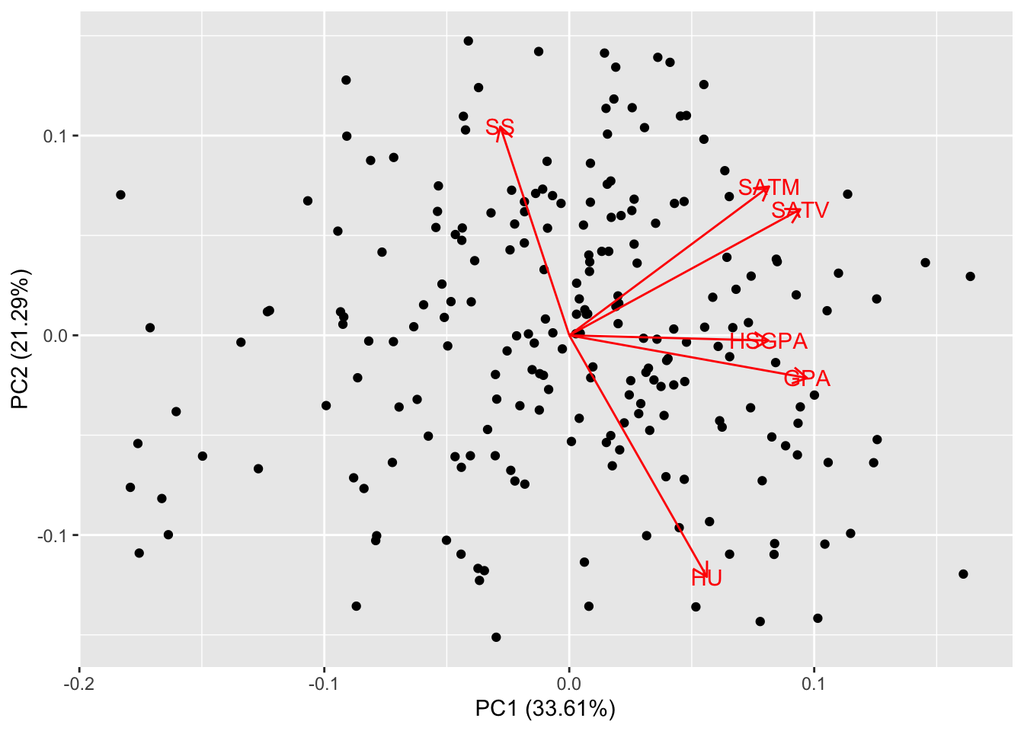

```r
## autoplot
autoplot(pca, loadings = TRUE, loadings.label = TRUE,
         data = gpa_2 , color = 'FirstGen')
```

```r
## percentage of variance
percent <- 100 * pca$sdev^2 / sum(pca$sdev^2)
percent
```

```
## [1] 33.612990 21.290283 18.123663 11.902467  7.737003  7.333594
```

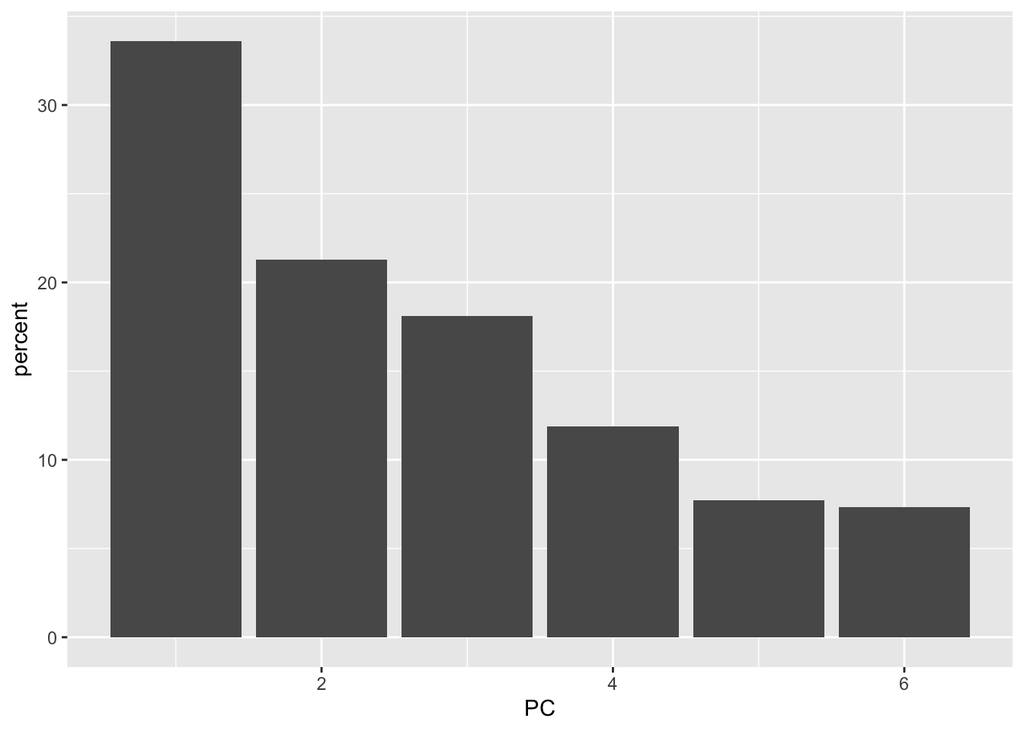

```r
var_data <- data.frame(percent = percent, PC = 1:length(percent))
ggplot(var_data, aes(x = PC, y = percent)) +
  geom_col()
```

Using the autoplot, it seems that SAT scores and both GPAs greatly impact the first principal component, whereas social sciences credits and humanities credits moderately impacts the first principal component. Furthermore, it seems that social studies and humanities credits greatly impact the second principal component, whereas SAT scores moderately impact the second PC and GPAs barely impact the second PC.

Lastly, the PCs that I retained captured 100% of the variance in the data.